# R Notebook

Objective: Determine trends in activity patterns with respect to both weather and routine to predict and inform/improve future behavior.

Install packages.

```r
devtools::install_github("avsecz/fitbitr")
devtools::install_github("r-lib/httr#485")
install.packages("jsonlite")
```

```
Error in install.packages : Updating loaded packages
```

```r
install.packages("mongolite")
install.packages("lubridate")
install.packages("RCurl")
install.packages("XML")
install.packages("jsonlite")
```

```
Error in install.packages : Updating loaded packages
```

```r
install.packages("ggplot2")
install.packages("Metrics")
```

Load packages.

```r
library("fitbitr")
library("httr")
library("jsonlite")
library("mongolite")
library("lubridate")
library("RCurl")
library("XML")
library("ggplot2")
library("Metrics")
token <- get_fitbit_token()
```

```
Use a local file ('.httr-oauth'), to cache OAuth access credentials between R sessions?

1: Yes
2: No
```

```r
install.packages("jsonlite")
2
```

```
Waiting for authentication in browser...
Press Esc/Ctrl + C to abort
Authentication complete.
```

Pull raw activity data (JSON) from Fitbit API from 2016-06-23 (when I first began wearing the fitbit) to present.

```r
req <-
fitbit_GET("1/user/4QXD3G/activities/steps/date/2016-06-23/2017-12-02.json",
token = token)
output <- toJSON(fitbit_parse(req))
output
```

[output not shown]

```r
# ts <- ts(rev(output$sleep$minutesAsleep), start=c(1, 1), end=c(19, 1), frequency=1)
```

Convert JSON to data frame.

```r
output <- fromJSON(output, simplifyDataFrame = TRUE)
output
```

```
$`activities-steps`
```

|  | dateTime | value |
| --- | --- | --- |
| 1 |  |  |
| 2 |  |  |
| 3 |  |  |
| 4 |  |  |
| 5 |  |  |
| 6 |  |  |
| 7 |  |  |
| 8 |  |  |
| 9 |  |  |
| 10 |  |  |

[output cut: 518 more lines]

```
NA
```

Clean activity data. Unlist JSON elements into columns. Convert data types and rename value column.

```r
data <- output$`activities-steps`
data$dateTime <- unlist(data$dateTime)
data$stepCount <- unlist(data$stepCount)
data
```

|  | dateTime | value |
| --- | --- | --- |
| 1 | 2016-06-23 |  |
| 2 | 2016-06-24 |  |
| 3 | 2016-06-25 |  |
| 4 | 2016-06-26 |  |
| 5 | 2016-06-27 |  |
| 6 | 2016-06-28 |  |
| 7 | 2016-06-29 |  |
| 8 | 2016-06-30 |  |
| 9 | 2016-07-01 |  |
| 10 | 2016-07-02 |  |

[output cut: 518 more lines]

```r
colnames(data)[2] <- "stepCount"
data$dateTime <- as.Date(data$dateTime, "%Y-%m-%d")
data$stepCount <- as.integer(data$stepCount)
```

Add additional date information features for day of the week and number week of the year.

```r
day <- weekdays(data$dateTime)
week <- week(data$dateTime)
data <- cbind(data, day, week)
data
```

|  | dateTime | stepCount | day | week |
| --- | --- | --- | --- | --- |
| 1 | 2016-06-23 | 5123 | Thursday | 25 |
| 2 | 2016-06-24 | 7219 | Friday | 26 |
| 3 | 2016-06-25 | 5713 | Saturday | 26 |
| 4 | 2016-06-26 | 22149 | Sunday | 26 |
| 5 | 2016-06-27 | 16140 | Monday | 26 |
| 6 | 2016-06-28 | 7348 | Tuesday | 26 |
| 7 | 2016-06-29 | 5170 | Wednesday | 26 |
| 8 | 2016-06-30 | 7440 | Thursday | 26 |
| 9 | 2016-07-01 | 3267 | Friday | 27 |
| 10 | 2016-07-02 | 4687 | Saturday | 27 |

[output cut: 518 more lines]

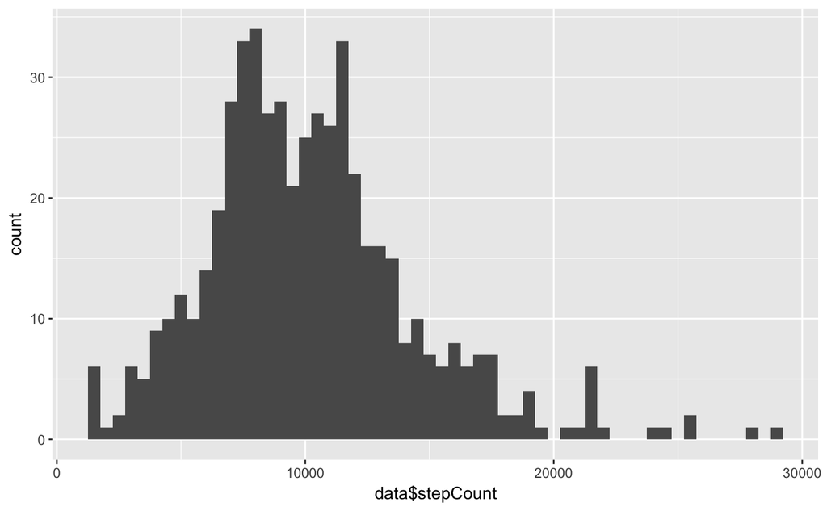

```r
qplot(data$stepCount,
      geom="histogram",
      binwidth=500)
```

Create function to scrape weather data from https://www.wunderground.com/ for a given time period. (The source is unable to provide history for very large periods of time and therefore must be retrieved in batches).

```r
getUrl <- function (date1, date2) {
  # Assemble proper url to retrieve weather data from webpage.
  # Arguments: date1, date2 are strings representing the start and end date in the format 'YYYY/mm/dd'
  # Returns: the customized url
  URL <-
  paste(
  "https://www.wunderground.com/history/airport/KBOS/",
  date1,
  "/CustomHistory.html?dayend=",
  substr(date2, 9, 10),
  "&monthend=",
  substr(date2, 6, 7),
  "&yearend=",
  substr(date2, 1, 4),
  "&req_city=&req_state=&req_statename=&reqdb.zip=&reqdb.magic=&reqdb.wmo=",
  sep = ""
  )
  return (URL)
}
fetchWeather <- function(startDate, endDate) {
  # Retrieve weather data for a given date range from webpage.
  # Arguments: startDate, endDate are strings representing the start and end date in the format 'YYYY/mm/dd'
  # Returns: a data frame containing the date, temperature, humidity, wind, precipitation, and types of weather
  webpage <-
    RCurl::getURL(getUrl(startDate, endDate))
  tc <- textConnection(webpage)
  webpage <- readLines(tc)
  close(tc)
  pagetree <- htmlTreeParse(webpage, useInternalNodes = TRUE)
  weatherDate <-
  unlist(xpathApply(pagetree, "//*[@id='obsTable']/tbody/tr/td[1]/a", xmlValue))
  weatherTempHi <-
  unlist(xpathApply(
  pagetree,
  "//*[@id='obsTable']/tbody/tr/td[2]/span",
  xmlValue
  ))
  weatherTempLo <-
  unlist(xpathApply(
  pagetree,
  "//*[@id='obsTable']/tbody/tr/td[4]/span",
  xmlValue
  ))
  weatherHumidity <-
  unlist(xpathApply(
  pagetree,
  "//*[@id='obsTable']/tbody/tr/td[9]/span",
  xmlValue
  ))
  weatherWind <-
  unlist(xpathApply(
  pagetree,
  "//*[@id='obsTable']/tbody/tr/td[18]/span",
  xmlValue
  ))
  weatherPrecip <-
  unlist(xpathApply(
  pagetree,
  "//*[@id='obsTable']/tbody/tr/td[20]/span",
  xmlValue
  ))
  weatherType <-
  unlist(xpathApply(pagetree, "//*[@id='obsTable']/tbody/tr/td[21]", xmlValue))
  # cleaning
  weatherType <-
  weatherType[grepl("\n", weatherType)] # remove empty strings
  weatherType <- gsub("\n", "", weatherType)
  weatherType <- gsub("\t", "", weatherType)
  weatherType
  weatherRain <- grepl("Rain", weatherType)
  weatherThunder <- grepl("Thunderstorm", weatherType)
  weatherFog <- grepl("Fog", weatherType)
  weatherSnow <- grepl("Snow", weatherType)
  weatherFrame <-
  data.frame(
  weatherDate,
  weatherTempHi,
  weatherTempLo,
  weatherHumidity,
  weatherWind,
  weatherPrecip,
  weatherType,
  weatherRain,
  weatherThunder,
  weatherFog,
  weatherSnow,
  stringsAsFactors = FALSE)
  weatherFrame[, 1:6] <- sapply(weatherFrame[, 1:6], as.numeric)
  colnames(weatherFrame) <-
  c("date",
  "tempHi",
  "tempLo",
  "avgHumidity",
  "avgWind",
  "precip",
  "type",
  "rain",
  "thunder",
  "fog",
  "snow")
  return(weatherFrame)
}
weather2016 <- fetchWeather("2016/06/23", "2017/06/22")
```

```
NAs introduced by coercion
```

```r
weather2017 <- fetchWeather("2017/06/23", "2017/12/02")
```

```
NAs introduced by coercion
```

```r
weatherTotal <- rbind(weather2016, weather2017)
weatherTotal
```

| date | tempHi | tempLo | avgHumidity | avgWind | precip | type | rain | thunder | fog | snow |
| --- | --- | --- | --- | --- | --- | --- | --- | --- | --- | --- |
| 23 | 77 | 60 | 60 | 9 | 0.00 |  | FALSE | FALSE | FALSE | FALSE |
| 24 | 72 | 61 | 63 | 9 | 0.00 |  | FALSE | FALSE | FALSE | FALSE |
| 25 | 73 | 59 | 64 | 6 | 0.00 |  | FALSE | FALSE | FALSE | FALSE |
| 26 | 84 | 59 | 57 | 10 | 0.00 |  | FALSE | FALSE | FALSE | FALSE |
| 27 | 86 | 64 | 55 | 15 | 0.00 |  | FALSE | FALSE | FALSE | FALSE |
| 28 | 79 | 68 | 71 | 10 | 0.08 | Rain | TRUE | FALSE | FALSE | FALSE |
| 29 | 87 | 67 | 72 | 9 | 0.03 | Rain,Thunderstorm | TRUE | TRUE | FALSE | FALSE |
| 30 | 81 | 68 | 55 | 10 | 0.00 |  | FALSE | FALSE | FALSE | FALSE |
| 1 | 86 | 68 | 65 | 11 | 0.20 | Rain,Thunderstorm | TRUE | TRUE | FALSE | FALSE |
| 2 | 80 | 65 | 59 | 13 | 0.00 |  | FALSE | FALSE | FALSE | FALSE |

[output cut: 518 more lines]

Merge activity data frame with weather data frame.

```r
data <- cbind(data, weatherTotal[,2:11])
data
```

|  | dateTime | stepCount | day | week | tempHi | tempLo | avgHumidity | avgWind | precip | type | rain | thunder | fog | snow |
| --- | --- | --- | --- | --- | --- | --- | --- | --- | --- | --- | --- | --- | --- | --- |
| 1 | 2016-06-23 | 5123 | Thursday | 25 | 77 | 60 | 60 | 9 | 0.00 |  | FALSE | FALSE | FALSE | FALSE |
| 2 | 2016-06-24 | 7219 | Friday | 26 | 72 | 61 | 63 | 9 | 0.00 |  | FALSE | FALSE | FALSE | FALSE |
| 3 | 2016-06-25 | 5713 | Saturday | 26 | 73 | 59 | 64 | 6 | 0.00 |  | FALSE | FALSE | FALSE | FALSE |
| 4 | 2016-06-26 | 22149 | Sunday | 26 | 84 | 59 | 57 | 10 | 0.00 |  | FALSE | FALSE | FALSE | FALSE |
| 5 | 2016-06-27 | 16140 | Monday | 26 | 86 | 64 | 55 | 15 | 0.00 |  | FALSE | FALSE | FALSE | FALSE |
| 6 | 2016-06-28 | 7348 | Tuesday | 26 | 79 | 68 | 71 | 10 | 0.08 | Rain | TRUE | FALSE | FALSE | FALSE |
| 7 | 2016-06-29 | 5170 | Wednesday | 26 | 87 | 67 | 72 | 9 | 0.03 | Rain,Thunderstorm | TRUE | TRUE | FALSE | FALSE |
| 8 | 2016-06-30 | 7440 | Thursday | 26 | 81 | 68 | 55 | 10 | 0.00 |  | FALSE | FALSE | FALSE | FALSE |
| 9 | 2016-07-01 | 3267 | Friday | 27 | 86 | 68 | 65 | 11 | 0.20 | Rain,Thunderstorm | TRUE | TRUE | FALSE | FALSE |
| 10 | 2016-07-02 | 4687 | Saturday | 27 | 80 | 65 | 59 | 13 | 0.00 |  | FALSE | FALSE | FALSE | FALSE |

[output cut: 518 more lines]

Check for missing values. Only the precipitation column contains missing values.

```r
sapply(data[,1:14], function(x) length(x[which(is.na(x) == TRUE)]))
```

```
   dateTime   stepCount         day        week      tempHi      tempLo avgHumidity     avgWind      precip        type
          0           0           0           0           0           0           0           0          56           0
       rain     thunder         fog        snow
          0           0           0           0
```

Exploratory visuals for precipitation.

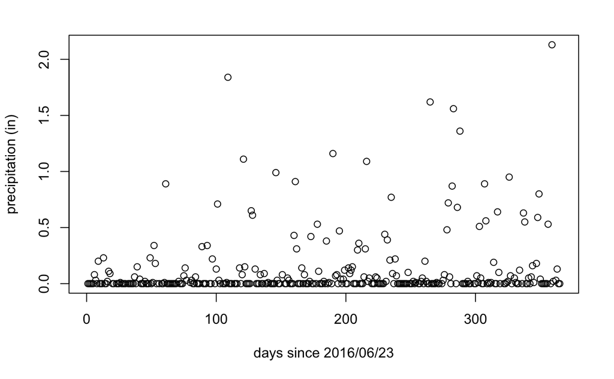

```r
# precipitation over a one year period
plot(weather2016$precip, xlab="days since 2016/06/23", ylab="precipitation (in)")
```

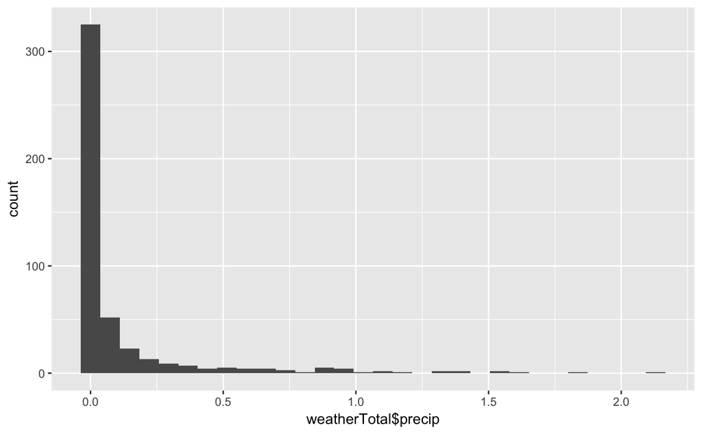

```r
# distribution of precipitation amounts
qplot(weatherTotal$precip,
      geom="histogram")
```

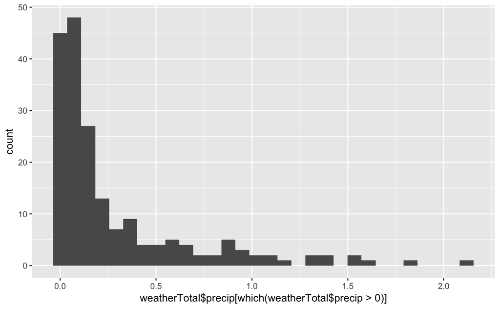

```r
# distribution of non-zero precipitation amounts
qplot(weatherTotal$precip[which(weatherTotal$precip>0)],
      geom="histogram")
```

Partition data into training and validation sets.

```r
set.seed(200)
sampleRows <- sample.int(nrow(data), size = nrow(data)*.75)
sampleRows
```

```
  [1] 282 308 311 363 350 439 372  51 273 123 236 336  80 335 197 158 291  68 471 329 234 521 105 466 161 134 361 191  16 261
 [31] 132  83 240 162 458 277  88 478 242 238 287 351 337  86 461 333  77 278 314 399  33  57 425 266 245  64  71  76 264 316
 [61]  69 267 354 470 360 480 101 130  44 520 163 472 213 126 181 142 265 511 290   3 366 332 292 514 445 349 204 435 164 523
 [91] 208  97  14 100 452 504 133 451 193 294 429 356  49 237  82  21 269   2 211 201 379  32  72 249 205 340 365  81 190   4
[121] 255 258 128 315 404 303 207 239 460 485 442 260 270 235 224 115 244 488  98 283 202 137 438 319 307  47 369 250 199 154
[151] 384  74 413 513 188 189 341  56 347 464 157 299  11 517  78 388 417  19 371 420 328   8  63  30 175 518  10 309 279  24
[181] 129  39 286 212 220 248  31 457  93 177 263 390 483 506 195 508 180 409 200 355 456 144 192 377 475 125  38 272 411 138
[211] 322 342   5  59 145 432 392 427 463 246  22 416 380 194  17 397  90   1 424 106 151 302 298 459  70 455 406 186 441 343
[241] 320 499 170 398 490 345 373 353 407 473  52 139 254 338 166 198 383  60 359 152 247 489 111 364  79  73 334  67 339 368
[271] 233 493 477 149  13 225 167   7 135 288 389 405 147 358  61 394  55 178  37 259 327 156 310 143 214  18 296 297 306 226
[301] 385 391  58 183 482 215 107 402 495 241 346  85 467 410 113 502 400 362  99 285 274 293 503  23 176 510 231 124 352 122
[331] 172 276  95 512 150  89 173 381  42 312  36 414 196 423  41  94  54 386  66 396 217  34 501 323  28 103 382  96 230 516
[361] 222 110 218 324 268  62 357  87 454 462 102 229 169 174 203 262 401 165 223  65  43 418 114 313 500 271 481 171 524 289
[391] 281 116 491 408   6 253
```

```r
trainingData <- data[sampleRows,]
trainingData <- trainingData[complete.cases(trainingData),]
trainingData
```

|  | dateTime | stepCount | day | week | tempHi | tempLo | avgHumidity | avgWind | precip | type | rain | thunder | fog | snow |
| --- | --- | --- | --- | --- | --- | --- | --- | --- | --- | --- | --- | --- | --- | --- |
| 282 | 2017-03-31 | 9297 | Friday | 13 | 40 | 33 | 82 | 13 | 0.87 | Fog,Rain,Snow | TRUE | FALSE | TRUE | TRUE |
| 308 | 2017-04-26 | 11657 | Wednesday | 17 | 56 | 45 | 100 | 10 | 0.56 | Fog,Rain | TRUE | FALSE | TRUE | FALSE |
| 311 | 2017-04-29 | 28112 | Saturday | 17 | 84 | 59 | 65 | 13 | 0.00 |  | FALSE | FALSE | FALSE | FALSE |
| 363 | 2017-06-20 | 10130 | Tuesday | 25 | 86 | 68 | 67 | 14 | 0.13 | Rain | TRUE | FALSE | FALSE | FALSE |
| 350 | 2017-06-07 | 19079 | Wednesday | 23 | 62 | 50 | 75 | 8 | 0.04 | Rain | TRUE | FALSE | FALSE | FALSE |
| 439 | 2017-09-04 | 15477 | Monday | 36 | 81 | 58 | 68 | 14 | 0.00 |  | FALSE | FALSE | FALSE | FALSE |
| 51 | 2016-08-12 | 6664 | Friday | 33 | 98 | 78 | 62 | 13 | 0.01 | Rain,Thunderstorm | TRUE | TRUE | FALSE | FALSE |
| 123 | 2016-10-23 | 7839 | Sunday | 43 | 58 | 44 | 50 | 20 | 0.00 |  | FALSE | FALSE | FALSE | FALSE |
| 236 | 2017-02-13 | 5641 | Monday | 7 | 34 | 24 | 79 | 20 | 0.09 | Snow | FALSE | FALSE | FALSE | TRUE |
| 336 | 2017-05-24 | 17390 | Wednesday | 21 | 64 | 54 | 84 | 6 | 0.00 |  | FALSE | FALSE | FALSE | FALSE |

[output cut: 342 more lines]

```r
validationData <- data[-sampleRows,]
validationData <- validationData[complete.cases(validationData),]
validationData
```

|  | dateTime | stepCount | day | week | tempHi | tempLo | avgHumidity | avgWind | precip | type | rain | thunder | fog | snow |
| --- | --- | --- | --- | --- | --- | --- | --- | --- | --- | --- | --- | --- | --- | --- |
| 9 | 2016-07-01 | 3267 | Friday | 27 | 86 | 68 | 65 | 11 | 0.20 | Rain,Thunderstorm | TRUE | TRUE | FALSE | FALSE |
| 12 | 2016-07-04 | 6517 | Monday | 27 | 88 | 66 | 46 | 12 | 0.00 |  | FALSE | FALSE | FALSE | FALSE |
| 15 | 2016-07-07 | 14382 | Thursday | 27 | 79 | 61 | 81 | 8 | 0.00 | Fog | FALSE | FALSE | TRUE | FALSE |
| 20 | 2016-07-12 | 8176 | Tuesday | 28 | 88 | 65 | 54 | 9 | 0.00 |  | FALSE | FALSE | FALSE | FALSE |
| 25 | 2016-07-17 | 15721 | Sunday | 29 | 79 | 68 | 79 | 7 | 0.00 |  | FALSE | FALSE | FALSE | FALSE |
| 26 | 2016-07-18 | 7536 | Monday | 29 | 95 | 67 | 65 | 12 | 0.01 | Rain,Thunderstorm | TRUE | TRUE | FALSE | FALSE |
| 27 | 2016-07-19 | 5098 | Tuesday | 29 | 84 | 68 | 51 | 11 | 0.00 |  | FALSE | FALSE | FALSE | FALSE |
| 29 | 2016-07-21 | 9565 | Thursday | 29 | 91 | 67 | 44 | 10 | 0.00 |  | FALSE | FALSE | FALSE | FALSE |
| 35 | 2016-07-27 | 9281 | Wednesday | 30 | 87 | 73 | 58 | 10 | 0.00 |  | FALSE | FALSE | FALSE | FALSE |
| 45 | 2016-08-06 | 12787 | Saturday | 32 | 89 | 70 | 67 | 12 | 0.02 | Rain | TRUE | FALSE | FALSE | FALSE |

[output cut: 110 more lines]

Create regression model to impute missing precipitation data.

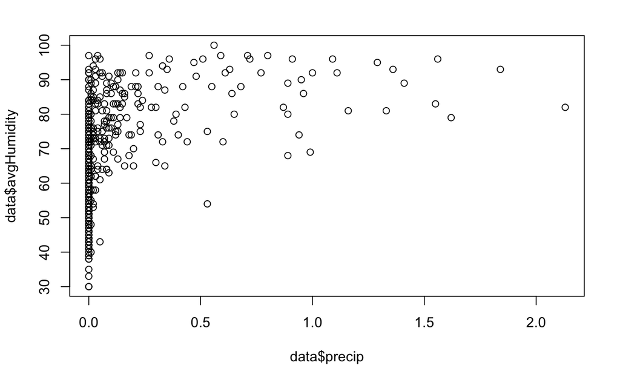

```r
plot(data$precip, data$avgHumidity)
```

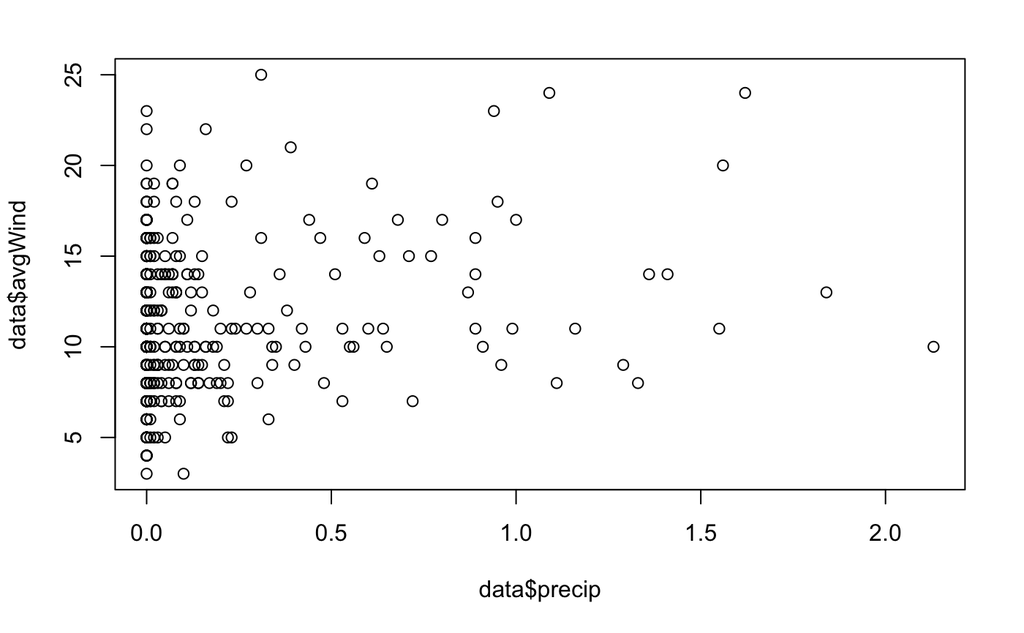

```r
plot(data$precip, data$avgWind)
```

```r
pred <- lm(precip ~
             week +
             tempHi +
             tempLo +
             avgHumidity +
             avgWind +
             type +
             rain +
             thunder +
             fog +
             snow,
             data = trainingData)
summary(pred)
```

```
Call:
lm(formula = precip ~ week + tempHi + tempLo + avgHumidity +
    avgWind + type + rain + thunder + fog + snow, data = trainingData)

Residuals:
     Min       1Q   Median       3Q      Max
-0.47682 -0.07226 -0.00991  0.03411  1.91138

Coefficients: (4 not defined because of singularities)
                             Estimate Std. Error t value Pr(>|t|)
(Intercept)                -3.229e-01  1.030e-01  -3.134 0.001876 **
week                        5.671e-05  8.166e-04   0.069 0.944674
tempHi                     -2.127e-03  2.173e-03  -0.979 0.328381
tempLo                      1.794e-03  2.427e-03   0.739 0.460359
avgHumidity                 4.151e-03  1.130e-03   3.674 0.000278 ***
avgWind                     1.125e-02  3.204e-03   3.512 0.000506 ***
typeFog                    -6.759e-02  7.910e-02  -0.855 0.393389
typeFog,Rain                8.276e-02  7.565e-02   1.094 0.274717
typeFog,Rain,Snow           7.985e-01  9.274e-02   8.611 2.89e-16 ***
typeFog,Rain,Thunderstorm   1.185e+00  2.090e-01   5.669 3.10e-08 ***
typeFog,Snow                5.221e-02  1.089e-01   0.480 0.631808
typeRain                    1.360e-01  3.415e-02   3.983 8.35e-05 ***
typeRain,Snow               5.398e-02  9.126e-02   0.592 0.554584
typeRain,Snow,Thunderstorm  1.059e+00  2.073e-01   5.110 5.42e-07 ***
typeRain,Thunderstorm       4.065e-01  6.074e-02   6.693 9.21e-11 ***
typeSnow                   -1.835e-02  7.452e-02  -0.246 0.805638
typeThunderstorm           -2.087e-02  2.068e-01  -0.101 0.919662
rainTRUE                           NA         NA      NA       NA
thunderTRUE                        NA         NA      NA       NA
fogTRUE                            NA         NA      NA       NA
snowTRUE                           NA         NA      NA       NA
---
Signif. codes:  0 ‘***’ 0.001 ‘**’ 0.01 ‘*’ 0.05 ‘.’ 0.1 ‘ ’ 1

Residual standard error: 0.2036 on 335 degrees of freedom
Multiple R-squared:  0.5001,    Adjusted R-squared:  0.4762
F-statistic: 20.95 on 16 and 335 DF,  p-value: < 2.2e-16
```

Backfit the model to remove statistically insignificant variables.

```r
pred <- lm(precip ~
             tempHi +
             tempLo +
             avgHumidity +
             avgWind +
             type,
             data = trainingData)
summary(pred)
```

```
Call:
lm(formula = precip ~ tempHi + tempLo + avgHumidity + avgWind +
    type, data = trainingData)

Residuals:
     Min       1Q   Median       3Q      Max
-0.47741 -0.07189 -0.00959  0.03295  1.91103

Coefficients:
                            Estimate Std. Error t value Pr(>|t|)
(Intercept)                -0.321541   0.100983  -3.184 0.001588 **
tempHi                     -0.002133   0.002168  -0.984 0.325865
tempLo                      0.001808   0.002414   0.749 0.454358
avgHumidity                 0.004153   0.001128   3.683 0.000269 ***
avgWind                     0.011240   0.003195   3.518 0.000495 ***
typeFog                    -0.067484   0.078963  -0.855 0.393364
typeFog,Rain                0.082454   0.075405   1.093 0.274967
typeFog,Rain,Snow           0.797932   0.092206   8.654  < 2e-16 ***
typeFog,Rain,Thunderstorm   1.184055   0.208341   5.683 2.87e-08 ***
typeFog,Snow                0.051128   0.107575   0.475 0.634900
typeRain                    0.135897   0.034045   3.992 8.06e-05 ***
typeRain,Snow               0.053860   0.091105   0.591 0.554792
typeRain,Snow,Thunderstorm  1.060752   0.206095   5.147 4.52e-07 ***
typeRain,Thunderstorm       0.406320   0.060569   6.708 8.36e-11 ***
typeSnow                   -0.019246   0.073281  -0.263 0.792997
typeThunderstorm           -0.020943   0.206471  -0.101 0.919266
---
Signif. codes:  0 ‘***’ 0.001 ‘**’ 0.01 ‘*’ 0.05 ‘.’ 0.1 ‘ ’ 1

Residual standard error: 0.2033 on 336 degrees of freedom
Multiple R-squared:  0.5001,    Adjusted R-squared:  0.4778
F-statistic: 22.41 on 15 and 336 DF,  p-value: < 2.2e-16
```

```r
pred <- lm(precip ~
             avgHumidity +
             avgWind +
             type,
             data = trainingData)
summary(pred)
```

```
Call:
lm(formula = precip ~ avgHumidity + avgWind + type, data = trainingData)

Residuals:
     Min       1Q   Median       3Q      Max
-0.48974 -0.07357 -0.01055  0.03831  1.90373

Coefficients:
                            Estimate Std. Error t value Pr(>|t|)
(Intercept)                -0.392651   0.078609  -4.995 9.45e-07 ***
avgHumidity                 0.004402   0.001017   4.329 1.97e-05 ***
avgWind                     0.011700   0.003162   3.701 0.000251 ***
typeFog                    -0.069734   0.078594  -0.887 0.375564
typeFog,Rain                0.084138   0.075090   1.121 0.263294
typeFog,Rain,Snow           0.806531   0.089564   9.005  < 2e-16 ***
typeFog,Rain,Thunderstorm   1.179441   0.206895   5.701 2.60e-08 ***
typeFog,Snow                0.066562   0.103511   0.643 0.520636
typeRain                    0.140932   0.033653   4.188 3.60e-05 ***
typeRain,Snow               0.061442   0.088747   0.692 0.489205
typeRain,Snow,Thunderstorm  1.067369   0.204688   5.215 3.22e-07 ***
typeRain,Thunderstorm       0.397205   0.059922   6.629 1.34e-10 ***
typeSnow                    0.000282   0.069557   0.004 0.996768
typeThunderstorm           -0.048375   0.204459  -0.237 0.813112
---
Signif. codes:  0 ‘***’ 0.001 ‘**’ 0.01 ‘*’ 0.05 ‘.’ 0.1 ‘ ’ 1

Residual standard error: 0.2031 on 338 degrees of freedom
Multiple R-squared:  0.4982,    Adjusted R-squared:  0.4789
F-statistic: 25.81 on 13 and 338 DF,  p-value: < 2.2e-16
```

```r
pred <- lm(precip ~
             avgHumidity +
             avgWind,
             data = trainingData)
summary(pred)
```

```
Call:
lm(formula = precip ~ avgHumidity + avgWind, data = trainingData)

Residuals:
     Min       1Q   Median       3Q      Max
-0.37157 -0.12222 -0.04563  0.04172  1.92679

Coefficients:
              Estimate Std. Error t value Pr(>|t|)
(Intercept) -0.6969737  0.0776456  -8.976  < 2e-16 ***
avgHumidity  0.0085233  0.0008694   9.804  < 2e-16 ***
avgWind      0.0201277  0.0035645   5.647 3.39e-08 ***
---
Signif. codes:  0 ‘***’ 0.001 ‘**’ 0.01 ‘*’ 0.05 ‘.’ 0.1 ‘ ’ 1

Residual standard error: 0.2451 on 349 degrees of freedom
Multiple R-squared:  0.2453,    Adjusted R-squared:  0.241
F-statistic: 56.72 on 2 and 349 DF,  p-value: < 2.2e-16
```

Determine accuracy of imputation model for precipitation to be 54.26%. While the model is not statistically powerful with a low adjusted r-squared value .241, it serves the purpose of imputing missing precipation values.

```r
predAccuracy <- round(predict(pred, trainingData, type="response"))
accuracy(predAccuracy, validationData$precip)
```

```
longer object length is not a multiple of shorter object length
```

```
[1] 0.5426136
```

Impute missing precipitation value.

```r
imputePrecip <- function(r) {
  # Given a row containing missing precipitation data, impute the missing value.
  # Arguments: row containing missing precip data
  # Returns: the predicted precipitation value for the entry

  precipPred <- (pred$coefficients[[1]] +
  (pred$coefficients[[2]] * r[7]) + (pred$coefficients[[3]] * r[8]))
  return(round(max(precipPred, 0), 2))
}
isWeatherEvent <- function(x) {
  # Determine if a particular date had a recorded weather event.
  # Arguments: string representing the 'type' field of the entry
  # Returns: true if the string matches any of the weather event types
  # Weather types  are hardcoded and this function should be abstracted to include all possible combinations more programmatically

  return(
  x == "Rain" |
  x == "Thunderstorm" |
  x == "Fog" |
  x == "Snow" |
  x == "Fog,Rain" |
  x == "Rain,Thunderstorm" |
  x == "Fog,Rain,Thunderstorm" |
  x == "Fog,Rain,Snow" |
  x == "Fog,Snow" |
  x == "Rain,Snow" |
  x == "Rain,Snow,Thunderstorm"
  )
}
# for data points where no weather events were recorded, impute precipitation of 0.00 if precipitation is NA
data[which(!isWeatherEvent(data$type)), ][is.na(data[which(!isWeatherEvent(data$type)), ]$precip), ]$precip <- 0.00
# for data points where a weather event was recorded, impute precipitation
incompleteCases <- data[is.na(data$precip), ]
imputedPrecip <- sapply(1:34, function(x) imputePrecip(incompleteCases[x, ])[[1]])
data[is.na(data$precip), ]$precip <- imputedPrecip
sapply(data[, 1:14], function(x)
length(x[which(is.na(x) == TRUE)])) # confirm that there are no remaining missing values
```

```
   dateTime   stepCount         day        week      tempHi      tempLo avgHumidity     avgWind      precip        type
          0           0           0           0           0           0           0           0           0           0
       rain     thunder         fog        snow
          0           0           0           0
```

```r
data
```

|  | dateTime | stepCount | day | week | tempHi | tempLo | avgHumidity | avgWind | precip | type | rain | thunder | fog | snow |
| --- | --- | --- | --- | --- | --- | --- | --- | --- | --- | --- | --- | --- | --- | --- |
| 1 | 2016-06-23 | 5123 | Thursday | 25 | 77 | 60 | 60 | 9 | 0.00 |  | FALSE | FALSE | FALSE | FALSE |
| 2 | 2016-06-24 | 7219 | Friday | 26 | 72 | 61 | 63 | 9 | 0.00 |  | FALSE | FALSE | FALSE | FALSE |
| 3 | 2016-06-25 | 5713 | Saturday | 26 | 73 | 59 | 64 | 6 | 0.00 |  | FALSE | FALSE | FALSE | FALSE |
| 4 | 2016-06-26 | 22149 | Sunday | 26 | 84 | 59 | 57 | 10 | 0.00 |  | FALSE | FALSE | FALSE | FALSE |
| 5 | 2016-06-27 | 16140 | Monday | 26 | 86 | 64 | 55 | 15 | 0.00 |  | FALSE | FALSE | FALSE | FALSE |
| 6 | 2016-06-28 | 7348 | Tuesday | 26 | 79 | 68 | 71 | 10 | 0.08 | Rain | TRUE | FALSE | FALSE | FALSE |
| 7 | 2016-06-29 | 5170 | Wednesday | 26 | 87 | 67 | 72 | 9 | 0.03 | Rain,Thunderstorm | TRUE | TRUE | FALSE | FALSE |
| 8 | 2016-06-30 | 7440 | Thursday | 26 | 81 | 68 | 55 | 10 | 0.00 |  | FALSE | FALSE | FALSE | FALSE |
| 9 | 2016-07-01 | 3267 | Friday | 27 | 86 | 68 | 65 | 11 | 0.20 | Rain,Thunderstorm | TRUE | TRUE | FALSE | FALSE |
| 10 | 2016-07-02 | 4687 | Saturday | 27 | 80 | 65 | 59 | 13 | 0.00 |  | FALSE | FALSE | FALSE | FALSE |

[output cut: 518 more lines]

Detect outliers where stepCount is greater than or less than 3 standard deviations away from the mean.

```r
dataWOutliers <- data # make a copy of the data before removing outliers
dataMean <- mean(data$stepCount) # 10165.07
dataSd <- sd(data$stepCount) # 4223.689
outliers <- data[which((data$stepCount > (dataMean + 3 * dataSd)) |
(data$stepCount < (dataMean - 3 * dataSd))), ]
outliers
```

|  | dateTime | stepCount | day | week | tempHi | tempLo | avgHumidity | avgWind | precip | type | rain | thunder | fog | snow |
| --- | --- | --- | --- | --- | --- | --- | --- | --- | --- | --- | --- | --- | --- | --- |
| 311 | 2017-04-29 | 28112 | Saturday | 17 | 84 | 59 | 65 | 13 | 0.00 |  | FALSE | FALSE | FALSE | FALSE |
| 379 | 2017-07-06 | 25335 | Thursday | 27 | 83 | 61 | 60 | 10 | 0.00 |  | FALSE | FALSE | FALSE | FALSE |
| 404 | 2017-07-31 | 28755 | Monday | 31 | 80 | 61 | 62 | 9 | 0.00 |  | FALSE | FALSE | FALSE | FALSE |
| 405 | 2017-08-01 | 24663 | Tuesday | 31 | 80 | 67 | 70 | 9 | 0.00 |  | FALSE | FALSE | FALSE | FALSE |
| 407 | 2017-08-03 | 25750 | Thursday | 31 | 84 | 66 | 79 | 10 | 0.18 | Rain | TRUE | FALSE | FALSE | FALSE |
| 408 | 2017-08-04 | 23785 | Friday | 31 | 85 | 68 | 72 | 10 | 0.00 |  | FALSE | FALSE | FALSE | FALSE |

Remove outliers.

[output not shown]

[output cut: 512 more lines]

After removing outliers, the data shows a bell curve revealing a more normal distribution.

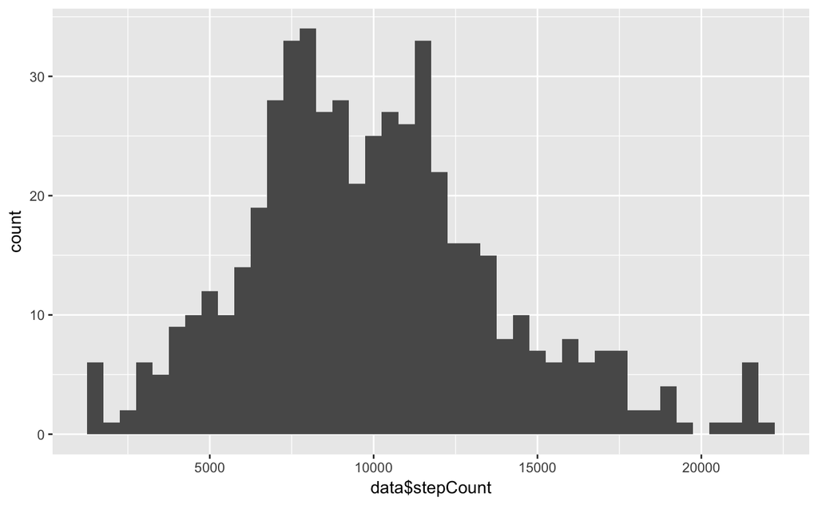

```r
qplot(data$stepCount,
      geom="histogram",
      binwidth=500)
```

Establish connection and insert data into mongodb collection.

```r
db$insert(data)
```

```
List of 5
 $ nInserted  : num 522
 $ nMatched   : num 0
 $ nRemoved   : num 0
 $ nUpserted  : num 0
 $ writeErrors: list()
```

```r
summary(pred)
```

[output not shown]